# PROSPECT logistic regression for urine loss - 1 year

Dr. Rianne Fijten

# build 1-year prediction models for urine loss

```r
trainingSet = allData1year[[1]]
trainingSet = trainingSet[,1:38]

testSet = allData1year[[2]]
testSet = testSet[,1:38]
```

Before we start, we’ll first remove the variables related to hot flashes and sensitive breasts as these are not to be included upon request by collaborators.

```r
trainingSet = trainingSet[,-grep("epic26_22_opvliegers1", names(trainingSet))]
trainingSet = trainingSet[,-grep("epic26_23_gevoeligeborsten1", names(trainingSet))]

testSet = testSet[,-grep("epic26_22_opvliegers1", names(testSet))]
testSet = testSet[,-grep("epic26_23_gevoeligeborsten1", names(testSet))]
```

First we recreate the training and test set with only the input variables and the outcome we want, in this case *“epic26_1_urineverlies2”. We’ll also remove the outcome data that we’re not interested in right now from the training and test set.

```r
outcomeTraining = allData1year[[1]]$epic26_1_urineverlies2
outcomeTest = allData1year[[2]]$epic26_1_urineverlies2
```

Then we’ll visualize the distributions of this outcome for the training set to decide how to transform it into a binary classification. For this outcome, the numbers are reversed, with 5 being no urine loss and 1 being the most severe form of urine loss.

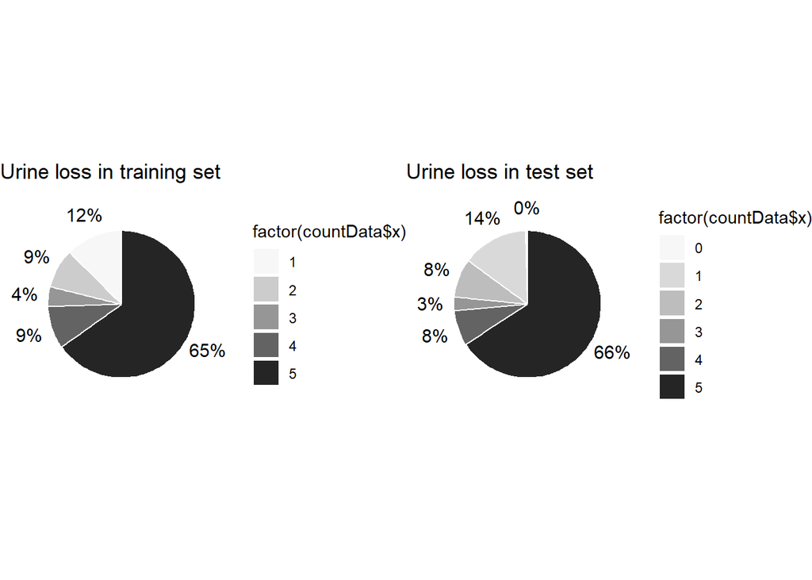

```r
pTraining = createPieChart(outcomeTraining, "Urine loss in training set")
pTest = createPieChart(outcomeTest, "Urine loss in test set")

multiplot(pTraining, pTest, cols = 2)
```

The test set contains one sample with answer 0 (which means NA). We’ll remove that one first.

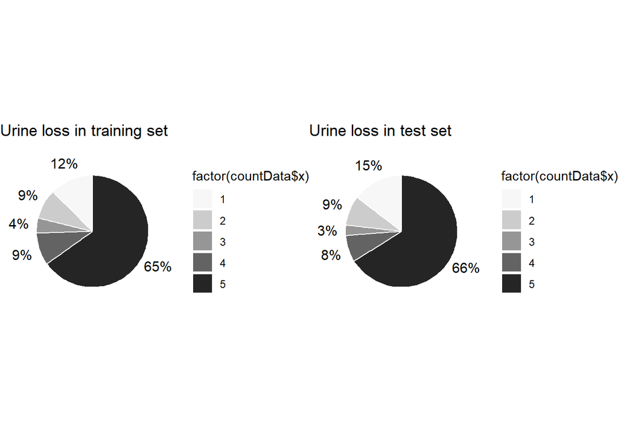

```r
testSet = testSet[-which(outcomeTest == 0),]
outcomeTest = outcomeTest[-which(outcomeTest == 0)]

pTraining = createPieChart(outcomeTraining, "Urine loss in training set")
pTest = createPieChart(outcomeTest, "Urine loss in test set")
multiplot(pTraining, pTest, cols = 2)
```

```r
alldata=rbind(trainingSet,testSet)
alloutcome=cbind(outcomeTraining,outcomeTest)
```

```r
adjacencyList = createAdjacencyList(cbind(trainingSet$treatments, outcomeTraining))

nodeNames = c("Prostatectomy", "EBRT", "Brachy", "Active surveillance", "MEER DAN 1X PER DAG", "ONGEVEER 1X PER DAG", "MEER DAN 1X PER WEEK", "ONGEVEER 1X PER WEEK", "ZELDEN OF NOOIT")
createSankeyDiagram(adjacencyList, nodeNames)
```

[interactive chart not shown]

This figure represents a clear case for the effect of treatment on the outcome 1 year after diagnosis. Patients that underwent active surveillance rare or never had urine loss issues. Prostatectomy patients however did suffer from urine loss, frequently the most severe form of urine loss.

Now we’ll make our binary dataset

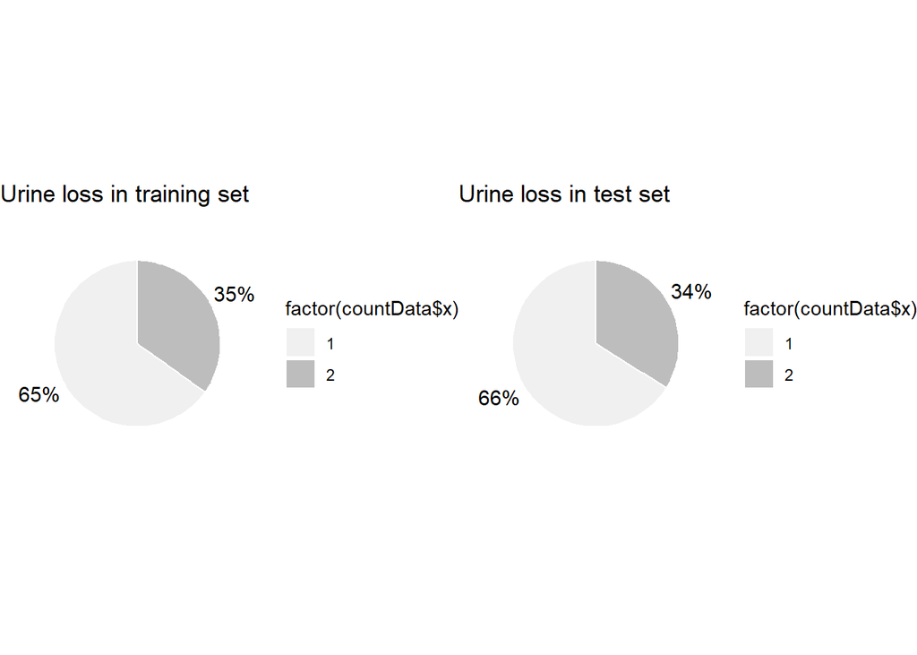

```r
binaryOutcomeTraining = createBinaryDataset(outcomeTraining, 5, seq(from = 1, to = 4))
binaryOutcomeTest = createBinaryDataset(outcomeTest, 5, seq(from = 1, to = 4))

pTrainingBinary = createPieChart(binaryOutcomeTraining, "Urine loss in training set")
pTestBinary = createPieChart(binaryOutcomeTest, "Urine loss in test set")

multiplot(pTrainingBinary, pTestBinary, cols = 2)
```

## Recursive Feature Elimination

Before going on to other methods, if necessary, we’ll first explore logistic regression with recursive feature elimination. We’ll save this RFE logit model to a file since re-running the RFE will yield (slightly) different results each time. *(The creation of the RFE logit model and its saving have been commented out for the purpose of creating the Knitted RMarkdown file and a load is added instead.)*

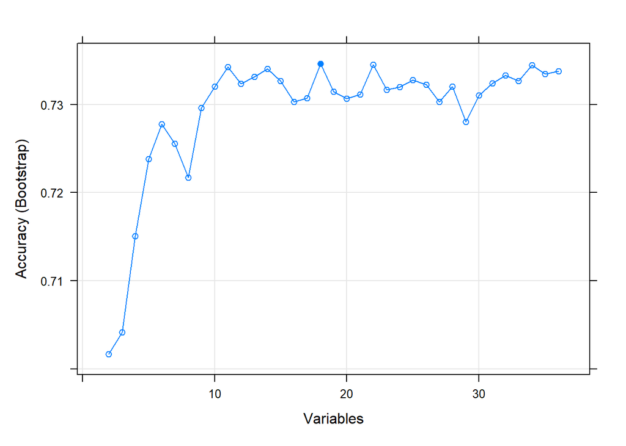

```r
#glmProfile = performLogitRfe(trainingSet, binaryOutcomeTraining)
 #saveRDS(glmProfile, "models/rfeResults_Incontinence_Urineloss_1year_noHotFlashesSensBreasts.rds")
glmProfile = readRDS("C:/Users/hajar.hasannejadasl/Documents/prospect2022/models/rfeResults_Incontinence_Urineloss_1year_noHotFlashesSensBreasts.rds")
plot(glmProfile, type=c("g", "o"))
```

We’ll now run logit models based on the variable importance retrieved by RFE.

```r
varImportance = calculateVariableImportance(glmProfile)
```

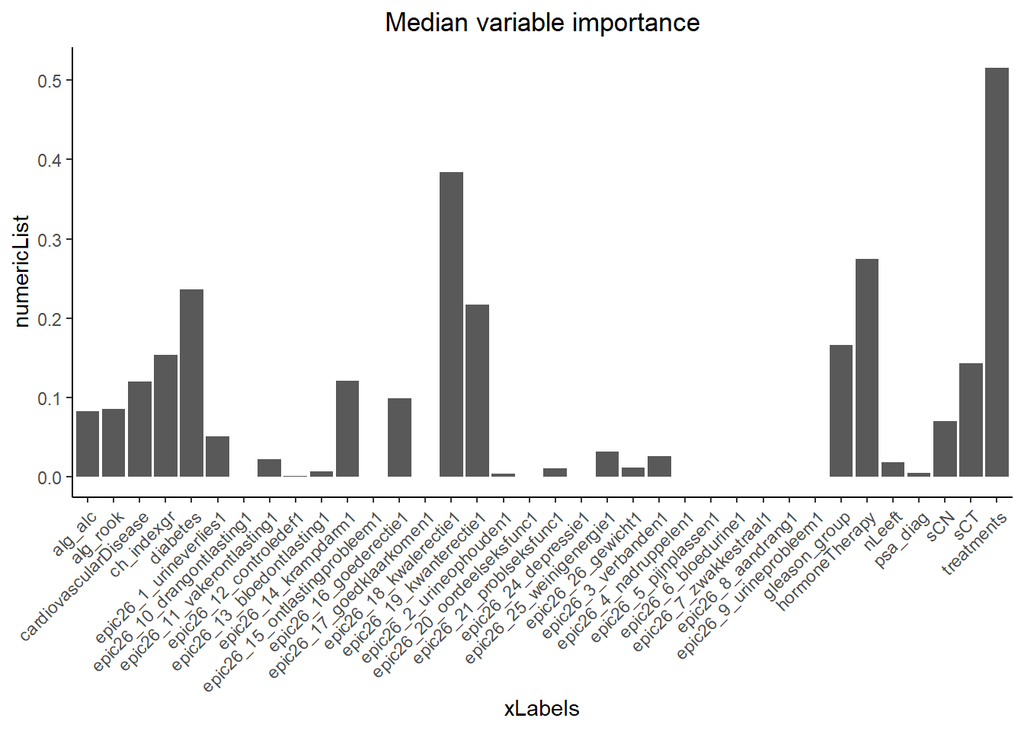

```r
allLogitModels = reduceVariablesLogit(trainingSet, binaryOutcomeTraining, varImportance)
```

```
## [1] 1
```

```
## [1] 2
```

```
## [1] 3
```

```
## [1] 4
```

```
## [1] 5
```

```
## [1] 6
```

```
## [1] 7
```

```
## [1] 8
```

```
## [1] 9
```

```
## [1] 10
```

```
## [1] 11
```

```
## [1] 12
```

```
## [1] 13
```

```
## [1] 14
```

```
## [1] 15
```

```
## [1] 16
```

```
## [1] 17
```

```
## [1] 18
```

```
## [1] 19
```

```
## [1] 20
```

```
## [1] 21
```

```
## [1] 22
```

```
## [1] 23
```

```
## [1] 24
```

```
## [1] 25
```

```
## [1] 26
```

```
## [1] 27
```

```
## [1] 28
```

```
## [1] 29
```

```
## [1] 30
```

```
## [1] 31
```

```
## [1] 32
```

```
## [1] 33
```

```
## [1] 34
```

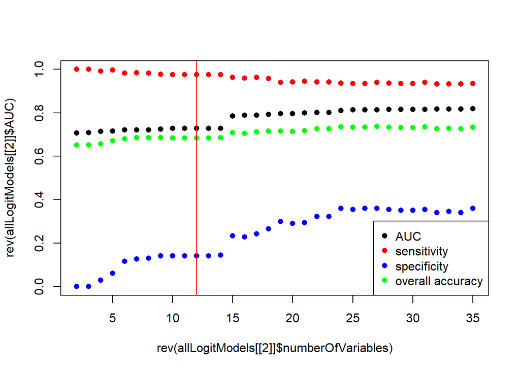

```r
{plot(rev(allLogitModels[[2]]$numberOfVariables), rev(allLogitModels[[2]]$AUC), ylim = c(0, 1), pch = 16)
  points(rev(allLogitModels[[2]]$numberOfVariables), rev(allLogitModels[[2]]$sensitivity), col = "red",  pch = 16)
  points(rev(allLogitModels[[2]]$numberOfVariables), rev(allLogitModels[[2]]$specificity), col =  "blue",  pch = 16)
  points(rev(allLogitModels[[2]]$numberOfVariables), rev(allLogitModels[[2]]$overallAccuracy), col = "green",  pch = 16)
  abline(v=12, col = "red")
  legend("bottomright", legend = c("AUC", "sensitivity", "specificity", "overall accuracy"), col = c("black", "red", "blue", "green"), pch = 16)}
```

# Prediction after Upsampling of the smaller dataset

To correct for this problem, we will need to perform upsampling as to balance the dataset. Then we’ll run RFE again

## Upsampling on class 2 (patients with problems)

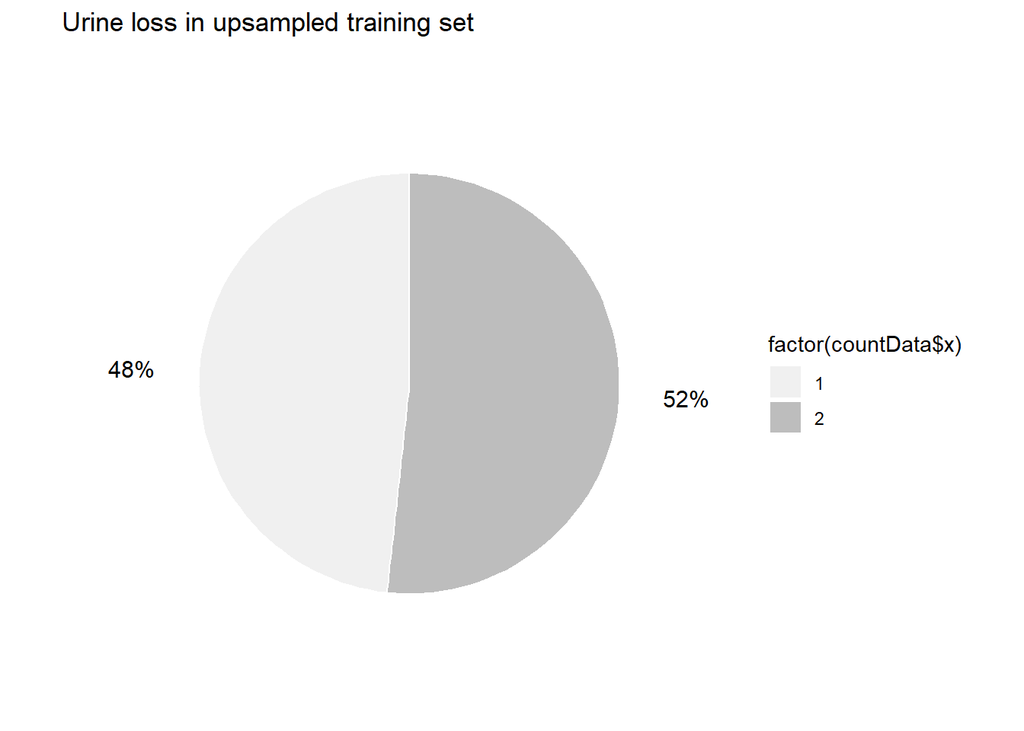

```r
library(smotefamily)
trainingSet2 <- data.frame(cbind(trainingSet,binaryOutcomeTraining))
trainingSet2$binaryOutcomeTraining <- as.factor(trainingSet2$binaryOutcomeTraining)
smote <- smotefamily::SMOTE(trainingSet2[,-which(colnames(trainingSet2) == "binaryOutcomeTraining")], trainingSet2$binaryOutcomeTraining, K=5, dup_size = 1)
datasmote=smote$data
SMOTE2BinaryOutcomeTraining = (datasmote[,c(37)])
SMOTE2TrainingSet = datasmote[,-c(37)]
createPieChart(datasmote$class, "Urine loss in upsampled training set")
```

The SMOTE function has generated 214 syntheic data. The dataset is now almost fully balanced.

## Recursive feature elimination

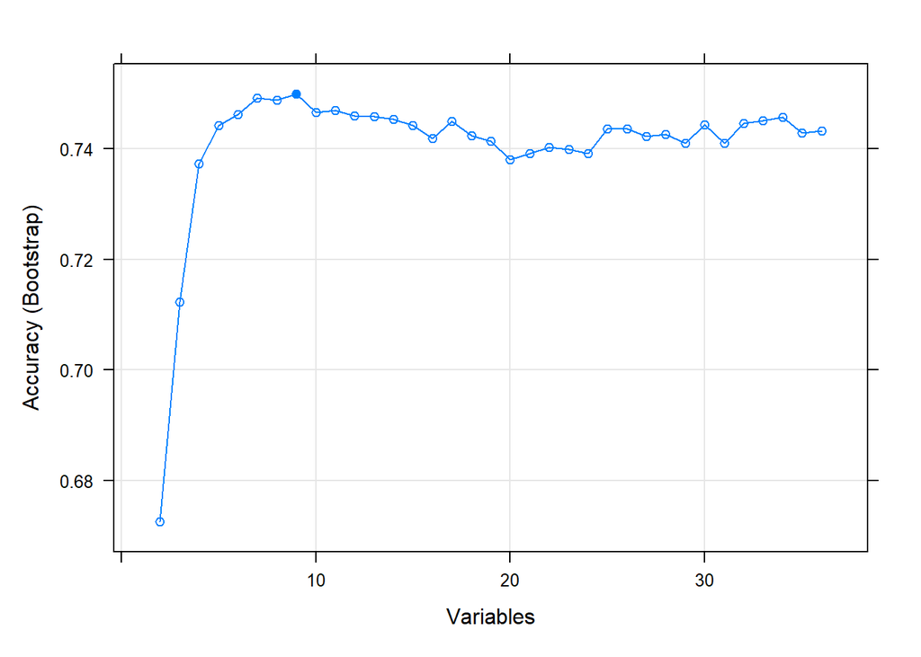

```r
#SMOTE2glmProfileUpsampled = performLogitRfe(SMOTE2TrainingSet, SMOTE2BinaryOutcomeTraining)
#saveRDS(SMOTE2glmProfileUpsampled, "models/rfeResults_Incontinence_Urineloss_1year_upsampled_noHotFlashesSensBreastsSMOTE2.rds")
SMOTE2glmProfileUpsampled = readRDS("C:/Users/hajar.hasannejadasl/Documents/prospect2022/models/rfeResults_Incontinence_Urineloss_1year_upsampled_noHotFlashesSensBreastsSMOTE2.rds")

plot(SMOTE2glmProfileUpsampled, type=c("g", "o"))
```

We’ll now run logit models based on the variable importance retrieved by RFE.

```r
varImportance = calculateVariableImportance(SMOTE2glmProfileUpsampled)
```

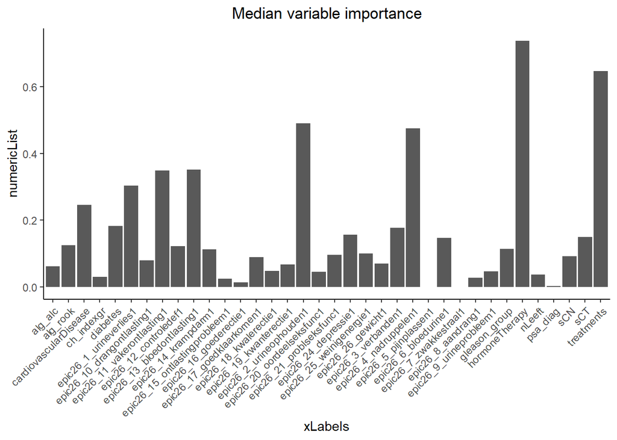

```r
allLogitModels = reduceVariablesLogit(SMOTE2TrainingSet, SMOTE2BinaryOutcomeTraining, varImportance)
```

```
## [1] 1
```

```
## [1] 2
```

```
## [1] 3
```

```
## [1] 4
```

```
## [1] 5
```

```
## [1] 6
```

```
## [1] 7
```

```
## [1] 8
```

```
## [1] 9
```

```
## [1] 10
```

```
## [1] 11
```

```
## [1] 12
```

```
## [1] 13
```

```
## [1] 14
```

```
## [1] 15
```

```
## [1] 16
```

```
## [1] 17
```

```
## [1] 18
```

```
## [1] 19
```

```
## [1] 20
```

```
## [1] 21
```

```
## [1] 22
```

```
## [1] 23
```

```
## [1] 24
```

```
## [1] 25
```

```
## [1] 26
```

```
## [1] 27
```

```
## [1] 28
```

```
## [1] 29
```

```
## [1] 30
```

```
## [1] 31
```

```
## [1] 32
```

```
## [1] 33
```

```
## [1] 34
```

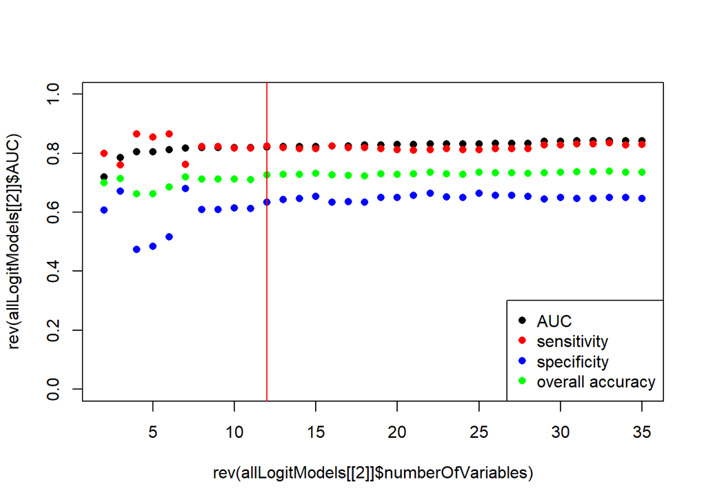

```r
{plot(rev(allLogitModels[[2]]$numberOfVariables), rev(allLogitModels[[2]]$AUC), ylim = c(0, 1), pch = 16)
  points(rev(allLogitModels[[2]]$numberOfVariables), rev(allLogitModels[[2]]$sensitivity), col = "red",  pch = 16)
  points(rev(allLogitModels[[2]]$numberOfVariables), rev(allLogitModels[[2]]$specificity), col =  "blue",  pch = 16)
  points(rev(allLogitModels[[2]]$numberOfVariables), rev(allLogitModels[[2]]$overallAccuracy), col = "green",  pch = 16)
  abline(v=12, col = "red")
  legend("bottomright", legend = c("AUC", "sensitivity", "specificity", "overall accuracy"), col = c("black", "red", "blue", "green"), pch = 16)}
```

```r
#Checking the performance metrics
allLogitModels[2]
```

```
## [[1]]
##          AUC sensitivity specificity overallAccuracy numberOfVariables
## 1  0.8416005      0.8300   0.6471963       0.7355072                35
## 2  0.8416647      0.8275   0.6495327       0.7355072                34
## 3  0.8414720      0.8350   0.6495327       0.7391304                33
## 4  0.8415245      0.8325   0.6471963       0.7367150                32
## 5  0.8414778      0.8325   0.6471963       0.7367150                31
## 6  0.8408879      0.8275   0.6495327       0.7355072                30
## 7  0.8408236      0.8275   0.6448598       0.7330918                29
## 8  0.8334784      0.8150   0.6542056       0.7318841                28
## 9  0.8332447      0.8150   0.6565421       0.7330918                27
## 10 0.8333324      0.8150   0.6565421       0.7330918                26
## 11 0.8324445      0.8125   0.6635514       0.7355072                25
## 12 0.8324650      0.8125   0.6495327       0.7282609                24
## 13 0.8320006      0.8150   0.6518692       0.7306763                23
```

[output cut: 21 more lines]

Choosing the model with 10 variables The variables in this model and their coefficients are:

```r
 # chosenModel = 10
 # SMOTE2glmProfile = allLogitModels[[1]][[dim(trainingSet)[2] + 1 - chosenModel]]
 # saveRDS(SMOTE2glmProfile, "C:/Users/hajar.hasannejadasl/Documents/prospect2022/models/rfeResults_Incontinence_Urineloss_1year_upsampled2_individual_noHotFlashesSensBreastsSMOTE2.rds")
SMOTE2glmProfile = readRDS("C:/Users/hajar.hasannejadasl/Documents/prospect2022/models/rfeResults_Incontinence_Urineloss_1year_upsampled2_individual_noHotFlashesSensBreastsSMOTE2.rds")
SMOTE2glmProfile$coefficients
```

```
##                (Intercept)                   diabetes
##                 4.53672692                 0.04234529
##      cardiovascularDisease     epic26_1_urineverlies1
##                 0.36832274                -0.28259002
## epic26_11_vakerontlasting1 epic26_13_bloedontlasting1
##                -0.51297620                 0.62172360
##      epic26_4_nadruppelen1    epic26_2_urineophouden1
##                 0.61691274                -0.49579705
##                 treatments             hormoneTherapy
##                -0.82162006                -1.13578699
```

Now we want know how this model performs on our training set first.

```r
trainingAccuracy = calculateAccuracy(SMOTE2glmProfile, SMOTE2BinaryOutcomeTraining)
trainingAccuracy[[1]] # sensitivity/specificity
```

```
##   sensitivity specificity overallAccuracy
## 1        0.82    0.614486       0.7137681
```

```r
trainingAccuracy[[2]] # confusionMatrix
```

```
##    actualOutcomes
##       1   2
##   1 328 165
##   2  72 263
```

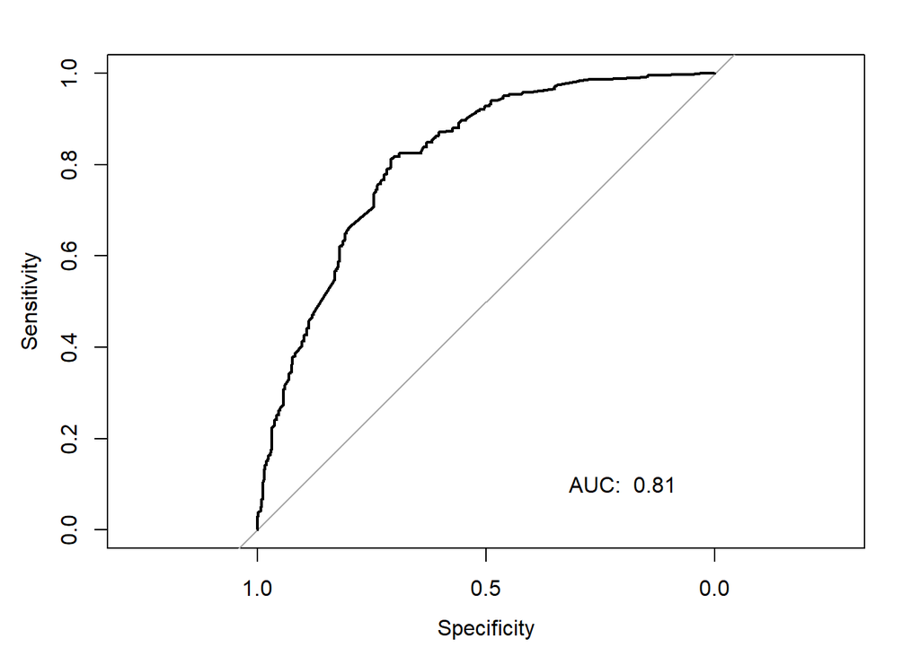

```r
createROCCurve(SMOTE2glmProfile, SMOTE2BinaryOutcomeTraining)
```

The sensitivity and specificity are not fully stabilized, but may be good enough to use.

```r
testAccuracy = calculateAccuracy(SMOTE2glmProfile, binaryOutcomeTest, testSet)
testAccuracy[[1]] # sensitivity/specificity
```

```
##   sensitivity specificity overallAccuracy
## 1   0.8246753   0.6329114       0.7596567
```

```r
testAccuracy[[2]] # confusionMatrix
```

```
##    actualOutcomes
##       1   2
##   1 127  29
##   2  27  50
```

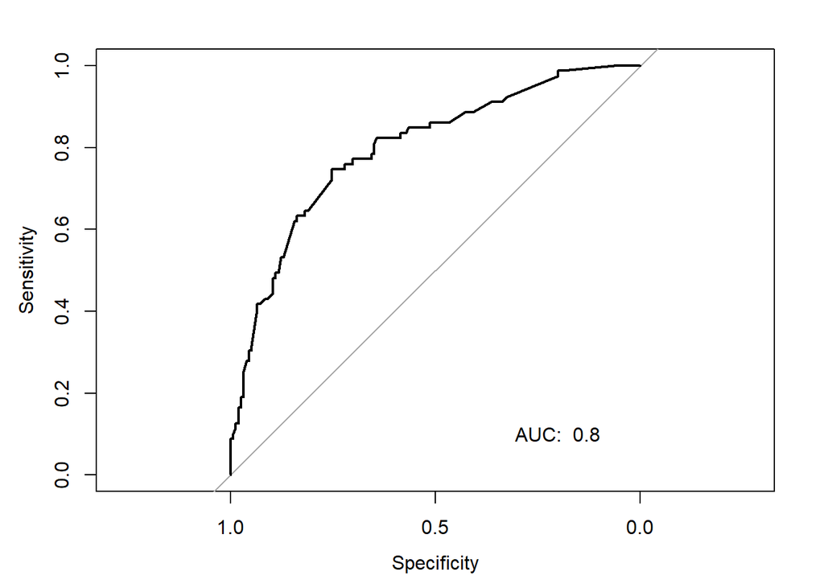

```r
createROCCurve(SMOTE2glmProfile, binaryOutcomeTest, testSet)
```

```r
test_prob = predict(SMOTE2glmProfile, testSet, type = "response")


SMOTE2glmProfile$coefficients
```

```
##                (Intercept)                   diabetes
##                 4.53672692                 0.04234529
##      cardiovascularDisease     epic26_1_urineverlies1
##                 0.36832274                -0.28259002
## epic26_11_vakerontlasting1 epic26_13_bloedontlasting1
##                -0.51297620                 0.62172360
##      epic26_4_nadruppelen1    epic26_2_urineophouden1
##                 0.61691274                -0.49579705
##                 treatments             hormoneTherapy
##                -0.82162006                -1.13578699
```

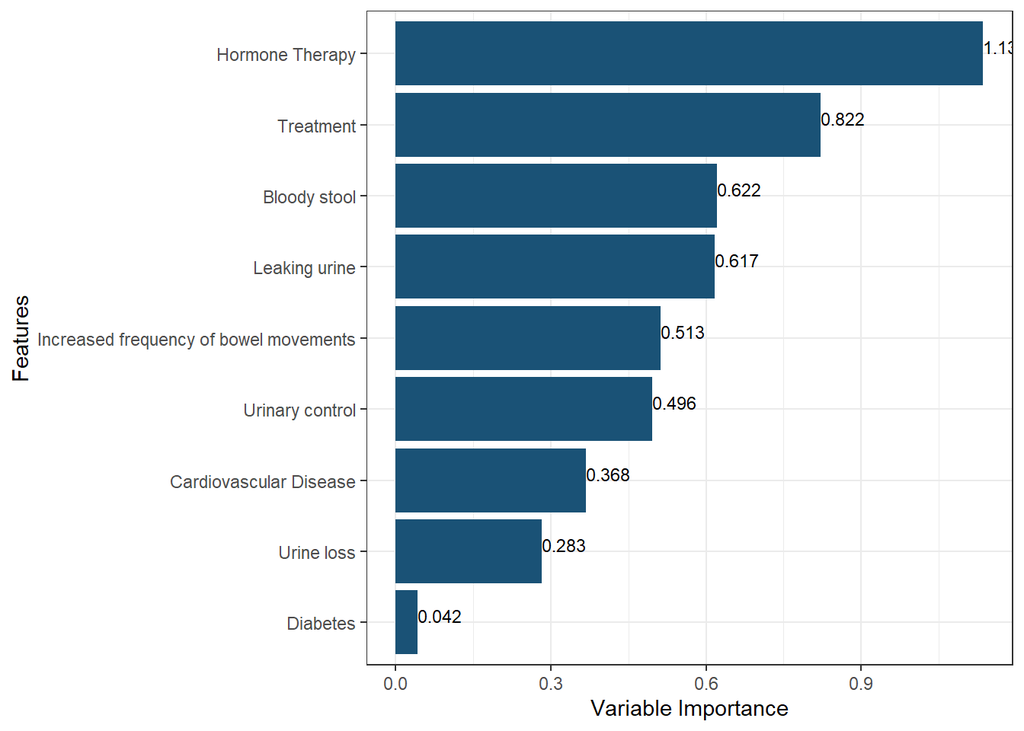

```r
#Var important

coef<-data.frame(SMOTE2glmProfile$coefficients)

coef <- tibble::rownames_to_column(coef,"Feature")

coef$importance<-abs(coef$SMOTE2glmProfile.coefficients)
coef<-coef[2:nrow(coef),]


coef<- coef[order(coef$importance, decreasing = TRUE),]
coef$name<-c("Hormone Therapy", "Treatment", "Bloody stool", "Leaking urine", "Increased frequency of bowel movements", "Urinary control", "Cardiovascular Disease", "Urine loss", "Diabetes")

ggplot(data = coef,
       aes(x = reorder(name, importance), y = importance, fill = "#1A5276")) +
   coord_flip() +
  geom_bar(stat="identity", fill="#1A5276") + labs(x = "Features", y = "Variable Importance") +
  geom_text(aes(label = round(importance,3)), vjust=0, hjust=0, color="black", size=3) +
  theme_bw() + theme(legend.position = "none")
```